# Practical 3

Student Number: S4555376, Name: Trevor Atkins

9/22/2020

## Part A

### 1. Importing Data and Creating a Markdown File

```r
Practical3a <- read.csv(file="Data-Practical3a.csv", head=TRUE, sep=";")
head(Practical3a)
```

```
##   Student teacher group Q1 Q2 Q3 Q4 Q5 Q6 Q7 Q8 Q9 Q10 Q11 Q12 Q13 Q14 Q15 Q16
## 1       1       A    1A 10  5  5  7  4  2  4 14  5   5   5   0   5   0   0   4
## 2       2       A    1A 12  5  4  8  4  4  5 18  5   0   5   0   0   5   0   4
## 3       3       A    1A 10  4  5  6  2  3  0  8  0   5   5   0   5   0   0   4
## 4       4       A    1A 18  5  6  8  5  3  4 15  5   5   5   0   5   0   5   4
## 5       5       A    1B 20  5  6  7  5  4  4 19  5   5   5   0   5   0   0   5
## 6       6       A    1A 16  5  6  8  6  3  1 19  0   0   5   0   5   0   0   4
##   Q17 TOTAL Grade
## 1  12    87     6
## 2  17    96     7
## 3  11    68     5
## 4  12   105     8
## 5  13   108     8
## 6  11    89     6
```

```r
Practical3a$TOTAL <- as.integer(Practical3a$TOTAL)
Practical3a$Student <- as.factor(Practical3a$Student)
Practical3a$teacher <- as.factor(Practical3a$teacher)
Practical3a$group <- as.factor(Practical3a$group)
str(Practical3a)
```

```
## 'data.frame':    130 obs. of  22 variables:
##  $ Student: Factor w/ 130 levels "1","2","3","4",..: 1 2 3 4 5 6 7 8 9 10 ...
##  $ teacher: Factor w/ 2 levels "A","B": 1 1 1 1 1 1 1 1 1 1 ...
##  $ group  : Factor w/ 5 levels "1A","1B","1C",..: 1 1 1 1 2 1 1 1 1 1 ...
##  $ Q1     : int  10 12 10 18 20 16 10 7 20 11 ...
##  $ Q2     : int  5 5 4 5 5 5 3 4 4 5 ...
##  $ Q3     : int  5 4 5 6 6 6 4 6 6 5 ...
##  $ Q4     : int  7 8 6 8 7 8 8 6 6 7 ...
##  $ Q5     : int  4 4 2 5 5 6 5 3 6 6 ...
##  $ Q6     : int  2 4 3 3 4 3 3 2 3 3 ...
##  $ Q7     : int  4 5 0 4 4 1 3 0 4 2 ...
##  $ Q8     : int  14 18 8 15 19 19 16 14 17 17 ...
##  $ Q9     : int  5 5 0 5 5 0 0 0 5 5 ...
##  $ Q10    : int  5 0 5 5 5 0 5 0 5 5 ...
##  $ Q11    : int  5 5 5 5 5 5 5 5 5 5 ...
##  $ Q12    : int  0 0 0 0 0 0 5 0 0 0 ...
##  $ Q13    : int  5 0 5 5 5 5 5 0 5 0 ...
##  $ Q14    : int  0 5 0 0 0 0 0 0 0 0 ...
##  $ Q15    : int  0 0 0 5 0 0 0 0 5 0 ...
##  $ Q16    : num  4 4 4 4 5 4 2 5 4 4 ...
##  $ Q17    : int  12 17 11 12 13 11 11 2 8 12 ...
##  $ TOTAL  : int  87 96 68 105 108 89 85 54 103 87 ...
##  $ Grade  : int  6 7 5 8 8 6 6 4 7 6 ...
```

### 2. Descriptives and Graphs for Groups

#### 2a

```r
install.packages("psych")
library("psych")
G1A <- subset(Practical3a, group == "1A")
G1B <- subset(Practical3a, group == "1B")
G1C <- subset(Practical3a, group == "1C")
G1D <- subset(Practical3a, group == "1D")
G1E <- subset(Practical3a, group == "1E")
aggregate(TOTAL~group, Practical3a, max)
```

```
##   group TOTAL
## 1    1A   106
## 2    1B   119
## 3    1C    92
## 4    1D   116
## 5    1E   116
```

```r
aggregate(TOTAL~group, Practical3a, min)
```

```
##   group TOTAL
## 1    1A    10
## 2    1B    22
## 3    1C    28
## 4    1D    22
## 5    1E    40
```

```r
aggregate(TOTAL~group, Practical3a, mean)
```

```
##   group    TOTAL
## 1    1A 76.07692
## 2    1B 81.24242
## 3    1C 64.56522
## 4    1D 69.00000
## 5    1E 73.08333
```

```r
aggregate(TOTAL~group, Practical3a, range)
```

```
##   group TOTAL.1 TOTAL.2
## 1    1A      10     106
## 2    1B      22     119
## 3    1C      28      92
## 4    1D      22     116
## 5    1E      40     116
```

```r
aggregate(TOTAL~group, Practical3a, sd)
```

```
##   group    TOTAL
## 1    1A 21.60726
## 2    1B 21.82033
## 3    1C 18.70543
## 4    1D 27.21732
## 5    1E 24.01072
```

```r
describe(Practical3a$TOTAL)
```

```
##    vars   n  mean    sd median trimmed   mad min max range  skew kurtosis   se
## X1    1 130 73.49 23.19     75   74.24 25.95  10 119   109 -0.28    -0.47 2.03
```

**Table 1:** Shows the Max, Min, Mean, Range, and Standard Deviation Proficiency Scores for the Students by Group

| value | Overall | G1A | G1B | G1C | G1D | G1E |
| --- | --- | --- | --- | --- | --- | --- |
| mean | 73.5 | 76.1 | 81.2 | 64.6 | 69.0 | 73.1 |
| max | 119 | 106 | 119 | 92 | 116 | 116 |
| min | 10 | 10 | 22 | 28 | 22 | 40 |
| range | 109 | 96 | 97 | 64 | 94 | 76 |
| sd | 23.2 | 21.6 | 21.8 | 18.7 | 27.2 | 24.0 |

1. The Group 1B seems to have performed the best.
2. The Group 1C performed most homogeneously.

#### 2b

```r
aggregate(TOTAL~teacher,Practical3a,mean)
```

```
##   teacher    TOTAL
## 1       A 78.40000
## 2       B 69.28571
```

```r
aggregate(TOTAL~teacher,Practical3a,sd)
```

```
##   teacher    TOTAL
## 1       A 21.95156
## 2       B 23.54960
```

Teacher A performed best as it scored more homogeneously (closer to the mean) and its mean is higher than Teacher B.

#### 2c

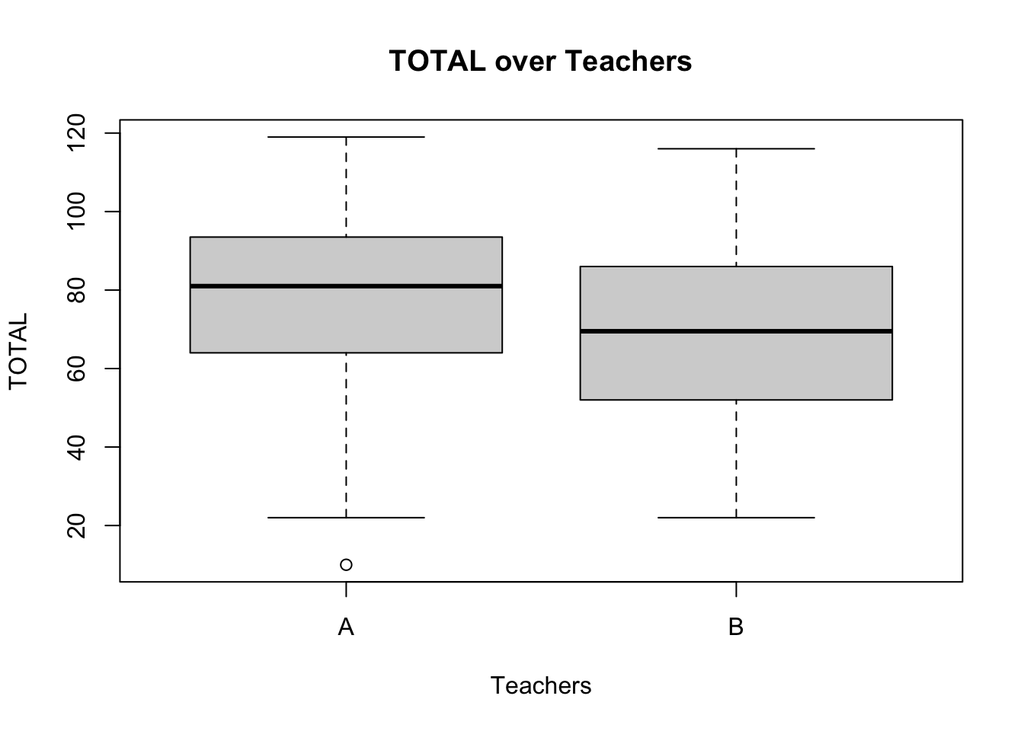

```r
boxplot(TOTAL~teacher, data=Practical3a, main="TOTAL over Teachers", xlab="Teachers", ylab="TOTAL")
```

**Figure 1:** Boxplot of Total Score over Teacher groups A&B

### 3. Checking for Normality

#### 3a

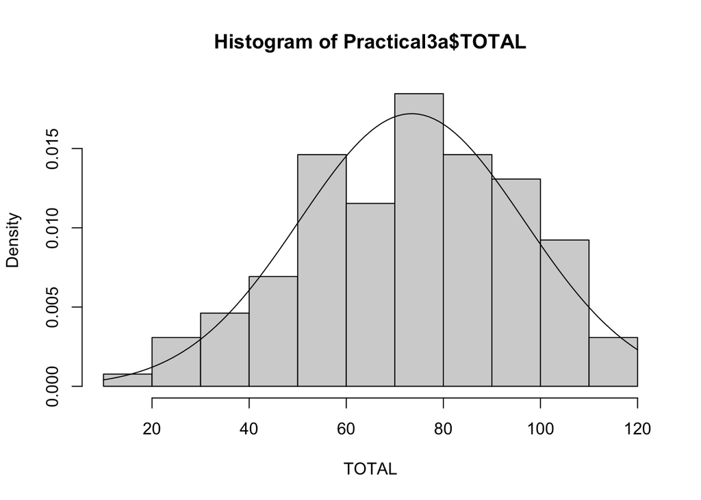

```r
hist(Practical3a$TOTAL, prob=TRUE, xlab="TOTAL")
curve(dnorm(x, mean=mean(Practical3a$TOTAL),sd=sd(Practical3a$TOTAL)), add=TRUE)
```

**Figure 2:** Histogram of Density over Total Score

#### 3b

At face value when looking at the histogram, the results approximately follow the normal distribution although there are some clear outliers.

### 4. Using Z-Scores

```r
scale(Practical3a$TOTAL, center = TRUE, scale = TRUE)
```

```
##               [,1]
##   [1,]  0.58244822
##   [2,]  0.97052591
##   [3,] -0.23682690
##   [4,]  1.35860360
##   [5,]  1.48796283
##   [6,]  0.66868771
##   [7,]  0.49620874
##   [8,] -0.84050330
##   [9,]  1.27236412
##  [10,]  0.58244822
##  [11,]  0.71180745
##  [12,]  0.79804694
##  [13,] -1.31482048
##  [14,] -2.73777201
```

[output cut: 120 more lines]

```r
Practical3a$zscore <- scale(Practical3a$TOTAL, center = TRUE, scale = TRUE)
S11 <- subset(Practical3a, student = "11")
S33 <- subset(Practical3a, student = "33")
S44 <- subset(Practical3a, student = "44")
S55 <- subset(Practical3a, student = "55")
by = c("11", "33", "44", "55")
dataframe = subset(Practical3a, Student %in% by)
show(dataframe)
```

```
##    Student teacher group Q1 Q2 Q3 Q4 Q5 Q6 Q7 Q8 Q9 Q10 Q11 Q12 Q13 Q14 Q15 Q16
## 11      11       A    1A 17  4  4  8  5  1  2 14  5   5   5   0   5   0   0   4
## 33      33       A    1B  3  4  0  5  2  2  0 11  0   0   0   0   0   0   0   2
## 44      44       A    1B 25  5  6  9  6  4  4 14  5   5   5   0   5   0   5   4
## 55      55       A    1B 14  5  6  7  6  4  2 11  0   5   5   5   5   0   5   4
##    Q17 TOTAL Grade     zscore
## 11  11    90     6  0.7118075
## 33   4    33     2 -1.7460179
## 44  17   119     9  1.9622800
## 55  15    99     7  1.0998851
```

Since the z-scores show how many standard deviations a student is away from the mean, Student 11 is 0.71 above the mean, Student 33 is 1.75 below the mean, Student 44 is 1.96 above the mean, and Student 55 is 1.10 above the mean.

### 5. Preparing for Inductive Statistics

#### 5a

My first impression about the difference between the groups of the two teachers is that the group of Teacher A based on TOTAL performs better than the group of Teacher B.

#### 5b

The null hypothesis belonging to the research question is that there is no significant difference between the total scores of the students of teacher A and the total scores of the students of teacher B.

#### 5c

```r
install.packages("pastecs")
library("pastecs")
stat.desc(Practical3a$TOTAL, basic=FALSE, norm=TRUE)
```

```
##       median         mean      SE.mean CI.mean.0.95          var      std.dev
##   75.0000000   73.4923077    2.0340057    4.0243300  537.8332737   23.1912327
##     coef.var     skewness     skew.2SE     kurtosis     kurt.2SE   normtest.W
##    0.3155600   -0.2798097   -0.6586535   -0.4701042   -0.5573098    0.9865427
##   normtest.p
##    0.2314139
```

```r
by(Practical3a$TOTAL, Practical3a$teacher, stat.desc,
basic=FALSE, norm=TRUE)
```

```
## Practical3a$teacher: A
##       median         mean      SE.mean CI.mean.0.95          var      std.dev
##  81.00000000  78.40000000   2.83393480   5.67069043 481.87118644  21.95156456
##     coef.var     skewness     skew.2SE     kurtosis     kurt.2SE   normtest.W
##   0.27999445  -0.73118727  -1.18432407   0.62067899   0.51001408   0.96340779
##   normtest.p
##   0.06913996
## ------------------------------------------------------------
## Practical3a$teacher: B
##       median         mean      SE.mean CI.mean.0.95          var      std.dev
##  69.50000000  69.28571429   2.81471605   5.61520488 554.58385093  23.54960405
##     coef.var     skewness     skew.2SE     kurtosis     kurt.2SE   normtest.W
##   0.33989119   0.07963182   0.13885212  -0.82629072  -0.72959704   0.98226327
##   normtest.p
##   0.42431929
```

The values of Skew.2SE and Kurt.2SE are within the -1.29 and 1.29 range: Skew.2SE for teacher A is -1.18 and Kurt.2SE for teacher A is 0.51. Skew.2SE for teacher B is 0.14 and Kurt.2SE is -0.73. Because the sample is of 130 students, we can assume that the values are close enough to a normal distribution. Since both teacher A and teacher B have Skew.2SE and Kurt.2SE values that are also within the -1.29 and 1.29 range, we can say that the data of the two teachers are normally distributed.

### 6. Checking for Normality Using a Test

#### 6b

```r
TA = subset(Practical3a, teacher == "A")
TB = subset(Practical3a, teacher == "B")
shapiro.test(as.numeric(unlist(TA)))
```

```
##
##  Shapiro-Wilk normality test
##
## data:  as.numeric(unlist(TA))
## W = 0.46728, p-value < 2.2e-16
```

```r
shapiro.test(as.numeric(unlist(TB)))
```

```
##
##  Shapiro-Wilk normality test
##
## data:  as.numeric(unlist(TB))
## W = 0.45112, p-value < 2.2e-16
```

For both teacher A and teacher B, the significance value is less than 2.2e-16, which means that it is not above 0.05 and it cannot be assumed that the data are normally distributed.

### 7. Checking for Equality of Variance

#### 7a

```r
sd(unlist(G1A))
```

```
## [1] 16.33577
```

```r
sd(unlist(G1B))
```

```
## [1] 19.48486
```

```r
sd(unlist(G1C))
```

```
## [1] 19.16235
```

```r
sd(unlist(G1D))
```

```
## [1] 23.54226
```

```r
sd(unlist(G1E))
```

```
## [1] 27.49295
```

The largest standard deviation is 27.5 and the smallest standard deviation is 16.3. These groups are equal in their variance, using the rule of thumb that the largest standard deviation is not more than twice as big as the smallest standard deviation.

#### 7b

In this case, H0 would be that there is no difference between the equal variance of the groups.

#### 7c

```r
install.packages('car')
library('car')
leveneTest(TOTAL~teacher, data=Practical3a)
```

```
## Levene's Test for Homogeneity of Variance (center = median)
##        Df F value Pr(>F)
## group   1   0.967 0.3273
##       128
```

### 8. Performing the T-Test

#### 8a

```r
 t.test(Practical3a$TOTAL ~ Practical3a$teacher, var.equal = FALSE)
```

```
##
##  Welch Two Sample t-test
##
## data:  Practical3a$TOTAL by Practical3a$teacher
## t = 2.2819, df = 127.08, p-value = 0.02416
## alternative hypothesis: true difference in means is not equal to 0
## 95 percent confidence interval:
##   1.210487 17.018085
## sample estimates:
## mean in group A mean in group B
##        78.40000        69.28571
```

#### 8b

The conclusion I would draw with regard to the research question in 2b is that the teacher group A performs better compared to teacher group B. The chance of incorrectly rejecting the H0 is 0.0242 or 2.42%. This means that we can reject the H0. My conclusion about the H0 is in line with what I would expect from the descriptives.

## Part B

```r
Practical3b <- read.csv(file="Data-Practical3b.csv", head=TRUE, sep=";")
head(Practical3b)
```

```
##   Participant Motivation Voc.Score
## 1           1        Low        22
## 2           2        Low        28
## 3           3       High        28
## 4           4        Low        26
## 5           5        Low        18
## 6           6        Low        31
```

```r
Practical3b$Participant <- as.factor(Practical3b$Participant)
Practical3b$Motivation <- as.factor(Practical3b$Motivation)
str(Practical3b)
```

```
## 'data.frame':    424 obs. of  3 variables:
##  $ Participant: Factor w/ 424 levels "1","2","3","4",..: 1 2 3 4 5 6 7 8 9 10 ...
##  $ Motivation : Factor w/ 2 levels "High","Low": 2 2 1 2 2 2 2 1 1 1 ...
##  $ Voc.Score  : int  22 28 28 26 18 31 22 25 20 25 ...
```

```r
High <- subset(Practical3b, Motivation == "High")
Low <- subset(Practical3b, Motivation == "Low")
aggregate(Voc.Score~Motivation, Practical3b, max)
```

```
##   Motivation Voc.Score
## 1       High        39
## 2        Low        37
```

```r
aggregate(Voc.Score~Motivation, Practical3b, min)
```

```
##   Motivation Voc.Score
## 1       High         9
## 2        Low         8
```

```r
aggregate(Voc.Score~Motivation, Practical3b, mean)
```

```
##   Motivation Voc.Score
## 1       High  23.88426
## 2        Low  22.86538
```

```r
aggregate(Voc.Score~Motivation, Practical3b, range)
```

```
##   Motivation Voc.Score.1 Voc.Score.2
## 1       High           9          39
## 2        Low           8          37
```

```r
aggregate(Voc.Score~Motivation, Practical3b, sd)
```

```
##   Motivation Voc.Score
## 1       High  5.219867
## 2        Low  5.243920
```

```r
describe(Practical3b$Voc.Score)
```

```
##    vars   n  mean   sd median trimmed  mad min max range  skew kurtosis   se
## X1    1 424 23.38 5.25     23   23.46 4.45   8  39    31 -0.09     0.27 0.25
```

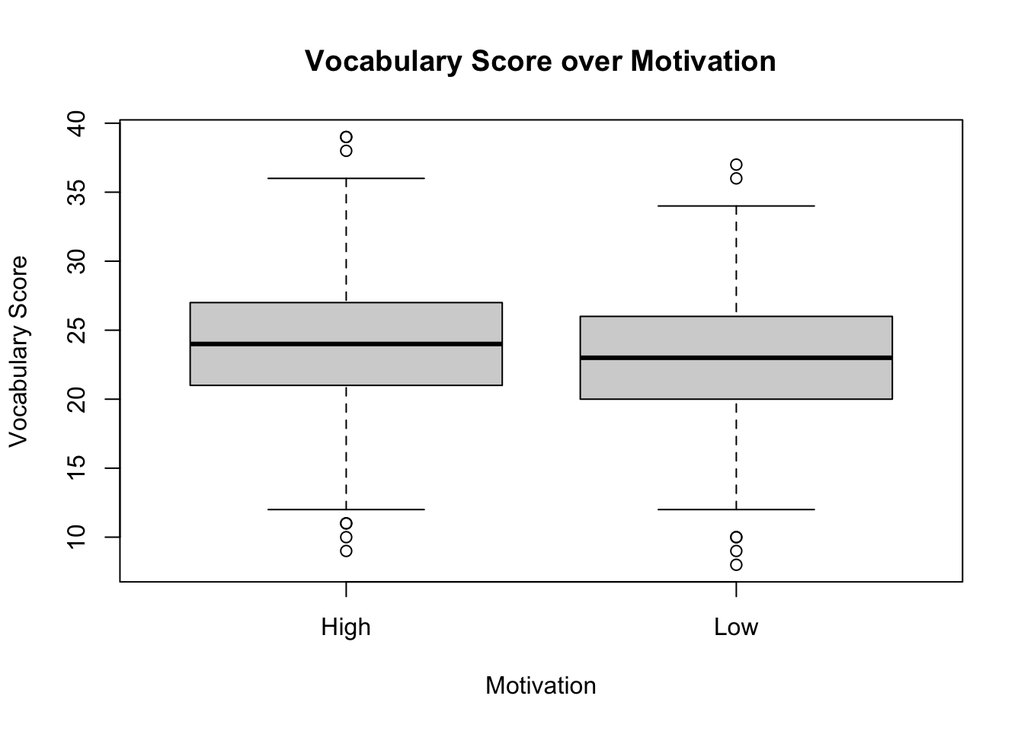

```r
boxplot(Voc.Score~Motivation, data=Practical3b, main="Vocabulary Score over Motivation", xlab="Motivation", ylab="Vocabulary Score")
```

**Figure 3:** Boxplot of Vocabulary Score over Motivation

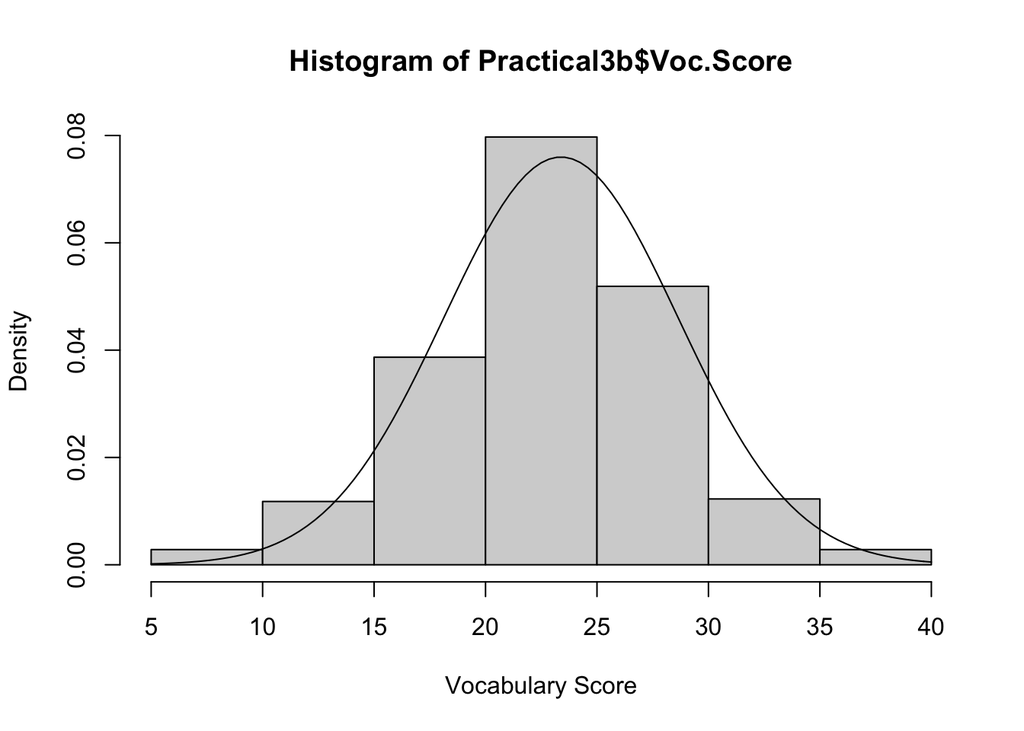

```r
hist(Practical3b$Voc.Score, prob=TRUE, xlab="Vocabulary Score")
curve(dnorm(x, mean=mean(Practical3b$Voc.Score),sd=sd(Practical3b$Voc.Score)), add=TRUE)
```

**Figure 4:** Histogram of Density over Vocabulary Score

```r
stat.desc(Practical3b$Voc.Score, basic=FALSE, norm=TRUE)
```

```
##       median         mean      SE.mean CI.mean.0.95          var      std.dev
##  23.00000000  23.38443396   0.25497784   0.50118139  27.56580914   5.25031515
##     coef.var     skewness     skew.2SE     kurtosis     kurt.2SE   normtest.W
##   0.22452180  -0.08889372  -0.37495312   0.27449594   0.58025231   0.99296579
##   normtest.p
##   0.04443836
```

```r
by(Practical3b$Voc.Score, Practical3b$Motivation, stat.desc,
basic=FALSE, norm=TRUE)
```

```
## Practical3b$Motivation: High
##       median         mean      SE.mean CI.mean.0.95          var      std.dev
##  24.00000000  23.88425926   0.35516693   0.70005502  27.24700689   5.21986656
##     coef.var     skewness     skew.2SE     kurtosis     kurt.2SE   normtest.W
##   0.21854840   0.04372938   0.13209317   0.44723142   0.67849436   0.99099767
##   normtest.p
##   0.20150683
## ------------------------------------------------------------
## Practical3b$Motivation: Low
##       median         mean      SE.mean CI.mean.0.95          var      std.dev
##  23.00000000  22.86538462   0.36360045   0.71683479  27.49869937   5.24392023
##     coef.var     skewness     skew.2SE     kurtosis     kurt.2SE   normtest.W
##   0.22933882  -0.22393648  -0.66397292  -0.02728182  -0.04063285   0.99180496
##   normtest.p
##   0.29387426
```

```r
shapiro.test(unlist(High))
```

```
##
##  Shapiro-Wilk normality test
##
## data:  unlist(High)
## W = 0.67926, p-value < 2.2e-16
```

```r
shapiro.test(unlist(Low))
```

```
##
##  Shapiro-Wilk normality test
##
## data:  unlist(Low)
## W = 0.68212, p-value < 2.2e-16
```

```r
leveneTest(Voc.Score~Motivation, data=Practical3b)
```

```
## Levene's Test for Homogeneity of Variance (center = median)
##        Df F value Pr(>F)
## group   1  0.1184 0.7309
##       422
```

```r
t.test(Practical3b$Voc.Score ~ Practical3b$Motivation, var.equal = FALSE)
```

```
##
##  Welch Two Sample t-test
##
## data:  Practical3b$Voc.Score by Practical3b$Motivation
## t = 2.0046, df = 421.24, p-value = 0.04565
## alternative hypothesis: true difference in means is not equal to 0
## 95 percent confidence interval:
##  0.01979307 2.01795621
## sample estimates:
## mean in group High  mean in group Low
##           23.88426           22.86538
```

**Table 2:** Shows the Max, Min, Mean, Range, and Standard Deviation Proficiency Scores for the Vocabulary Score by Motivation

| value | Overall | High | Low |  |  |  |
| --- | --- | --- | --- | --- | --- | --- |
| mean | 23.4 | 23.88 | 22.86 |  |  |  |
| max | 39 | 39 | 37 |  |  |  |
| min | 8 | 9 | 8 |  |  |  |
| range | 31 | 30 | 29 |  |  |  |
| sd | 5.25 | 5.22 | 5.24 |  |  |  |